# 重賞レース予測レポート【レース終了】

作成日時: 2026/09/06 16:20:29

☞ [マニュアル(pdf)](https://ryutoro-galois.github.io/keiba-predictor/manual/manual.pdf)

☞ 過去6年の同一レース結果: [2025年](https://ryutoro-galois.github.io/keiba-predictor/report/PredResult_2025y_raceDate_20250906_20250907.html), [2024年](https://ryutoro-galois.github.io/keiba-predictor/report/PredResult_2024y_raceDate_20240907_20240908.html), [2023年](https://ryutoro-galois.github.io/keiba-predictor/report/PredResult_2023y_raceDate_20230909_20230910.html), [2022年](https://ryutoro-galois.github.io/keiba-predictor/report/PredResult_2022y_raceDate_20220910_20220911.html), [2021年](https://ryutoro-galois.github.io/keiba-predictor/report/PredResult_2021y_raceDate_20210911_20210912.html), [2020年](https://ryutoro-galois.github.io/keiba-predictor/report/PredResult_2020y_raceDate_20200912_20200913.html)

☞ 過去4週間の別レース結果: [1週前(8/30)](https://ryutoro-galois.github.io/keiba-predictor/report/PredResult_2026y_raceDate_20260830_20260830.html), [2週前(8/23)](https://ryutoro-galois.github.io/keiba-predictor/report/PredResult_2026y_raceDate_20260823_20260823.html), [3週前(8/15-16)](https://ryutoro-galois.github.io/keiba-predictor/report/PredResult_2026y_raceDate_20260815_20260816.html), [4週前(8/8-9)](https://ryutoro-galois.github.io/keiba-predictor/report/PredResult_2026y_raceDate_20260808_20260809.html)

☞ レース結果(csv): [9/5-6](https://ryutoro-galois.github.io/keiba-predictor/csv/race_result_20260905_20260906.csv)

## 【レース結果(1)】人気と着順の関係

### 【京成杯オータムハンデ(2026/09/05(土))】

【京成杯オータムハンデ(GⅢ)】  
2026/09/05(土), 06_中山, 芝右外1600m

[interactive chart not shown]

### 【札幌2歳ステークス(2026/09/05(土))】

【札幌2歳ステークス(GⅢ)】  
2026/09/05(土), 01_札幌, 芝右1800m

[interactive chart not shown]

### 【紫苑ステークス(2026/09/06(日))】

[interactive chart not shown]

### 【セントウルステークス(2026/09/06(日))】

【セントウルステークス(GⅡ)】  
2026/09/06(日), 09_阪神, 芝右1200m

[interactive chart not shown]

## 【レース結果(2)】コーナー通過順位

### 【京成杯オータムハンデ(2026/09/05(土))】

【京成杯オータムハンデ(GⅢ)】  
2026/09/05(土), 06_中山, 芝右外1600m

[interactive chart not shown]

### 【札幌2歳ステークス(2026/09/05(土))】

【札幌2歳ステークス(GⅢ)】  
2026/09/05(土), 01_札幌, 芝右1800m

[interactive chart not shown]

### 【紫苑ステークス(2026/09/06(日))】

[interactive chart not shown]

### 【セントウルステークス(2026/09/06(日))】

【セントウルステークス(GⅡ)】  
2026/09/06(日), 09_阪神, 芝右1200m

[interactive chart not shown]

## 0. 推し馬予測 (AI予測)

### 【京成杯オータムハンデ(GⅢ) 2026/09/05(土)】

- 本命(◎): 1-3着内確率(勝負強さ)が1位の馬
- 対抗(◯): 1-3着内確率が2-N位(20%程度以上)の中で予測タイムが最も速い馬
- 3番手(▲): 1-3着内確率が2-N位(20%程度以上)のでダークホース確率が最も高い馬
- 穴: ダークホース確率が上位1-M位(40%程度以上)の中で1-3着内確率が最も高い馬

| 推し馬 | 枠番 | 馬番 | 人気 | オッズ | 馬名 | 騎手 | 調教師 | 予測タイム(sec) | 1_順位 | 1-3着内確率(%) | 2_順位 | ﾀﾞｰｸﾎｰｽ確率(%) | 3_順位 |
| --- | --- | --- | --- | --- | --- | --- | --- | --- | --- | --- | --- | --- | --- |
| 本命(◎) | 5 | 10 | 3 | 6.2 | ヴァルキリーバース | Ｃ．ルメール | 田中博康 | 93.5 | 7 | 54.1 | 1 | 0.4 | 13 |
| 対抗(◯) | 2 | 4 | 1 | 4.7 | フォルテアンジェロ | Ｄ．レーン | 上原佑紀 | 90.3 | 1 | 25.1 | 3 | 0.4 | 14 |
| 3番手(▲) | 6 | 12 | 7 | 11.9 | ディールメーカー | 横山武史 | 大和田成 | 95.2 | 8 | 20.9 | 5 | 0.9 | 9 |
| 穴 | 6 | 11 | 9 | 18.2 | クランフォード | 菊沢一樹 | 杉山晴紀 | 99.0 | 13 | 19.7 | 6 | 32.4 | 5 |

### 【札幌2歳ステークス(GⅢ) 2026/09/05(土)】

- 本命(◎): 1-3着内確率(勝負強さ)が1位の馬
- 対抗(◯): 1-3着内確率が2-N位(20%程度以上)の中で予測タイムが最も速い馬
- 3番手(▲): 1-3着内確率が2-N位(20%程度以上)のでダークホース確率が最も高い馬
- 穴: ダークホース確率が上位1-M位(40%程度以上)の中で1-3着内確率が最も高い馬

| 推し馬 | 枠番 | 馬番 | 人気 | オッズ | 馬名 | 騎手 | 調教師 | 予測タイム(sec) | 1_順位 | 1-3着内確率(%) | 2_順位 | ﾀﾞｰｸﾎｰｽ確率(%) | 3_順位 |
| --- | --- | --- | --- | --- | --- | --- | --- | --- | --- | --- | --- | --- | --- |
| 本命(◎) | 8 | 8 | 2 | 7.9 | テンカタイヘイ | 丹内祐次 | 小野次郎 | 113.2 | 2 | 29.0 | 1 | 1.5 | 6 |
| 対抗(◯) | 2 | 2 | 1 | 1.1 | ショウナンガレオン | 鮫島克駿 | 加藤士津八 | 108.5 | 1 | 21.2 | 2 | 0.4 | 9 |
| 3番手(▲) | 5 | 5 | 7 | 101.1 | ランダムナンバー | 古川吉洋 | 橋田宜長 | 120.6 | 5 | 5.5 | 6 | 24.6 | 2 |
| 穴 | 6 | 6 | 5 | 21.8 | ハヤブサカツオー | 吉田隼人 | 岡田稲男 | 120.7 | 6 | 9.7 | 5 | 1.8 | 5 |

- 本命(◎): 1-3着内確率(勝負強さ)が1位の馬
- 対抗(◯): 1-3着内確率が2-N位(20%程度以上)の中で予測タイムが最も速い馬
- 3番手(▲): 1-3着内確率が2-N位(20%程度以上)のでダークホース確率が最も高い馬
- 穴: ダークホース確率が上位1-M位(40%程度以上)の中で1-3着内確率が最も高い馬

| 推し馬 | 枠番 | 馬番 | 人気 | オッズ | 馬名 | 騎手 | 調教師 | 予測タイム(sec) | 1_順位 | 1-3着内確率(%) | 2_順位 | ﾀﾞｰｸﾎｰｽ確率(%) | 3_順位 |
| --- | --- | --- | --- | --- | --- | --- | --- | --- | --- | --- | --- | --- | --- |
| 本命(◎) | 7 | 9 | 1 | 2.5 | ドリームコア | Ｃ．ルメール | 田中博康 | 118.0 | 1 | 50.6 | 1 | 0.8 | 11 |
| 対抗(◯) | 6 | 7 | 11 | 56.9 | ロングトールサリー | 杉原誠人 | 福永祐一 | 127.4 | 2 | 9.8 | 5 | 74.4 | 1 |
| 3番手(▲) | 2 | 2 | 4 | 7.2 | サムシングスイート | 団野大成 | 伊藤大士 | 127.9 | 8 | 10.2 | 4 | 1.6 | 6 |
| 穴 | 8 | 11 | 7 | 15.0 | ベンヴェヌータ | 石橋脩 | 辻哲英 | 127.9 | 9 | 7.1 | 8 | 38.6 | 2 |

### 【セントウルステークス(GⅡ) 2026/09/06(日)】

- 本命(◎): 1-3着内確率(勝負強さ)が1位の馬
- 対抗(◯): 1-3着内確率が2-N位(20%程度以上)の中で予測タイムが最も速い馬
- 3番手(▲): 1-3着内確率が2-N位(20%程度以上)のでダークホース確率が最も高い馬
- 穴: ダークホース確率が上位1-M位(40%程度以上)の中で1-3着内確率が最も高い馬

| 推し馬 | 枠番 | 馬番 | 人気 | オッズ | 馬名 | 騎手 | 調教師 | 予測タイム(sec) | 1_順位 | 1-3着内確率(%) | 2_順位 | ﾀﾞｰｸﾎｰｽ確率(%) | 3_順位 |
| --- | --- | --- | --- | --- | --- | --- | --- | --- | --- | --- | --- | --- | --- |
| 本命(◎) | 3 | 5 | 4 | 7.0 | ダイヤモンドノット | 川田将雅 | 福永祐一 | 66.7 | 2 | 30.8 | 1 | 0.8 | 13 |
| 対抗(◯) | 6 | 12 | 7 | 24.1 | レッドモンレーヴ | 酒井学 | 蛯名正義 | 77.2 | 11 | 21.3 | 2 | 1.9 | 9 |
| 3番手(▲) | 8 | 15 | 8 | 28.6 | ビッグシーザー | Ｍ．デムーロ | 杉山晴紀 | 71.0 | 8 | 17.1 | 4 | 1.4 | 10 |
| 穴 | 3 | 6 | 16 | 226.5 | プロトポロス | 亀田温心 | 西村真幸 | 66.7 | 2 | 8.0 | 7 | 55.3 | 1 |

## 1. 予測チャート (タイム/勝負強さ)

### 【京成杯オータムハンデ(GⅢ)】

2026/09/05(土), 06_中山, 芝右外1600m

[interactive chart not shown]

### 【札幌2歳ステークス(GⅢ)】

2026/09/05(土), 01_札幌, 芝右1800m

[interactive chart not shown]

2026/09/06(日), 06_中山, 芝右2000m

[interactive chart not shown]

### 【セントウルステークス(GⅡ)】

2026/09/06(日), 09_阪神, 芝右1200m

[interactive chart not shown]

## 2. オッズモニタリング (毎時)

### 【京成杯オータムハンデ】

[interactive chart not shown]

### 【札幌2歳ステークス】

[interactive chart not shown]

### 【紫苑ステークス】

[interactive chart not shown]

### 【セントウルステークス】

[interactive chart not shown]

## 3. 出馬表

### 【京成杯オータムハンデ 2026/09/05(土) 】

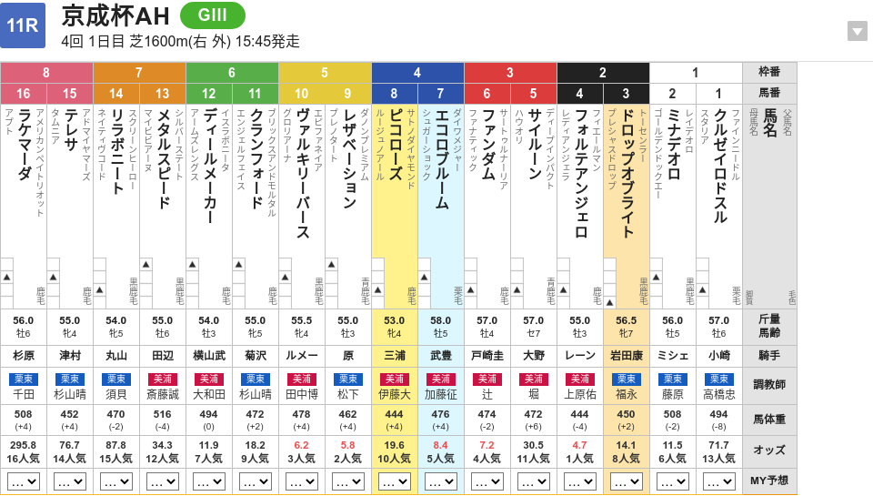

### 【札幌2歳ステークス 2026/09/05(土) 】

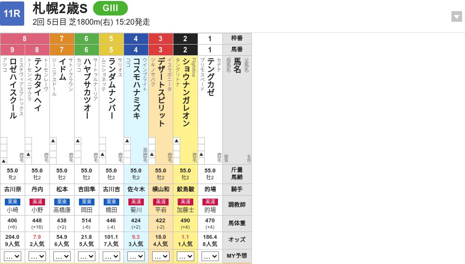

### 【紫苑ステークス 2026/09/06(日) 】

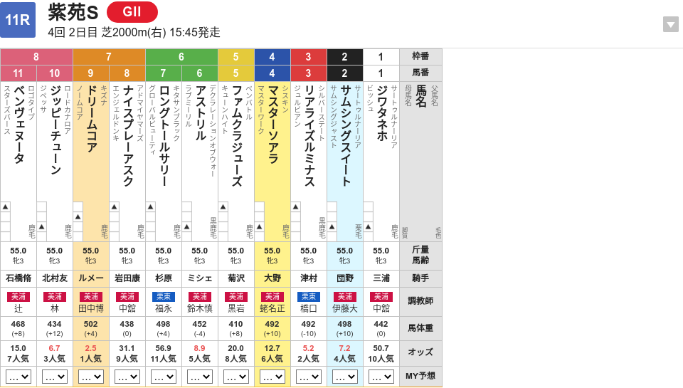

### 【セントウルステークス 2026/09/06(日) 】

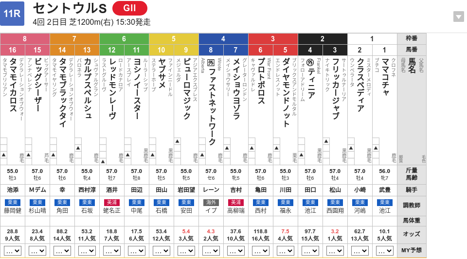

## 4. 単勝予測結果

### 【京成杯オータムハンデ(GⅢ) 2026/09/05(土)】

| 枠番 | 馬番 | 人気 | オッズ | 馬名 | 騎手 | 調教師 | 予測タイム(sec) | 1_順位 | 1-3着内確率(%) | 2_順位 | ﾀﾞｰｸﾎｰｽ確率(%) | 3_順位 |
| --- | --- | --- | --- | --- | --- | --- | --- | --- | --- | --- | --- | --- |
| 1 | 1 | 13 | 71.7 | クルゼイロドスル | 小崎綾也 | 高橋義忠 | 100.0 | 15 | 2.4 | 15 | 37.5 | 1 |
| 1 | 2 | 6 | 11.5 | ミナデオロ | Ｍ．ミシェル | 藤原英昭 | 98.7 | 12 | 8.6 | 9 | 0.5 | 11 |
| 2 | 3 | 8 | 14.1 | ドロップオブライト | 岩田康誠 | 福永祐一 | 98.7 | 11 | 5.6 | 13 | 0.8 | 10 |
| 2 | 4 | 1 | 4.7 | フォルテアンジェロ | Ｄ．レーン | 上原佑紀 | 90.3 | 1 | 25.1 | 3 | 0.4 | 14 |
| 3 | 5 | 11 | 30.5 | サイルーン | 大野拓弥 | 堀宣行 | 98.6 | 10 | 5.6 | 12 | 10.1 | 7 |
| 3 | 6 | 4 | 7.2 | ファンダム | 戸崎圭太 | 辻哲英 | 92.8 | 4 | 45.9 | 2 | 0.4 | 12 |
| 4 | 7 | 5 | 8.4 | エコロブルーム | 武豊 | 加藤征弘 | 92.5 | 3 | 18.5 | 7 | 0.4 | 15 |
| 4 | 8 | 10 | 19.6 | ピコローズ | 三浦皇成 | 伊藤大士 | 92.3 | 2 | 14.3 | 8 | 28.0 | 6 |
| 5 | 9 | 2 | 5.8 | レザベーション | 原優介 | 松下武士 | 99.7 | 14 | 23.8 | 4 | 0.4 | 16 |
| 5 | 10 | 3 | 6.2 | ヴァルキリーバース | Ｃ．ルメール | 田中博康 | 93.5 | 7 | 54.1 | 1 | 0.4 | 13 |

[output cut: 6 more lines]

### 【札幌2歳ステークス(GⅢ) 2026/09/05(土)】

| 枠番 | 馬番 | 人気 | オッズ | 馬名 | 騎手 | 調教師 | 予測タイム(sec) | 1_順位 | 1-3着内確率(%) | 2_順位 | ﾀﾞｰｸﾎｰｽ確率(%) | 3_順位 |
| --- | --- | --- | --- | --- | --- | --- | --- | --- | --- | --- | --- | --- |
| 1 | 1 | 8 | 186.4 | テングカゼ | 的場勇人 | 的場均 | 120.4 | 4 | 3.5 | 8 | 20.9 | 3 |
| 2 | 2 | 1 | 1.1 | ショウナンガレオン | 鮫島克駿 | 加藤士津八 | 108.5 | 1 | 21.2 | 2 | 0.4 | 9 |
| 3 | 3 | 4 | 18.0 | デザートスピリット | 横山和生 | 平岩大典 | 121.6 | 9 | 12.7 | 4 | 1.4 | 7 |
| 4 | 4 | 3 | 9.3 | コスモハナミズキ | 佐々木大輔 | 菊川正達 | 121.3 | 8 | 13.9 | 3 | 1.2 | 8 |
| 5 | 5 | 7 | 101.1 | ランダムナンバー | 古川吉洋 | 橋田宜長 | 120.6 | 5 | 5.5 | 6 | 24.6 | 2 |
| 6 | 6 | 5 | 21.8 | ハヤブサカツオー | 吉田隼人 | 岡田稲男 | 120.7 | 6 | 9.7 | 5 | 1.8 | 5 |
| 7 | 7 | 6 | 54.9 | イドム | 松本大輝 | 高橋康之 | 120.8 | 7 | 5.1 | 7 | 32.8 | 1 |
| 8 | 8 | 2 | 7.9 | テンカタイヘイ | 丹内祐次 | 小野次郎 | 113.2 | 2 | 29.0 | 1 | 1.5 | 6 |
| 8 | 9 | 9 | 204.0 | ロゼハイスクール | 古川奈穂 | 小崎憲 | 119.8 | 3 | 3.3 | 9 | 12.1 | 4 |

| 枠番 | 馬番 | 人気 | オッズ | 馬名 | 騎手 | 調教師 | 予測タイム(sec) | 1_順位 | 1-3着内確率(%) | 2_順位 | ﾀﾞｰｸﾎｰｽ確率(%) | 3_順位 |
| --- | --- | --- | --- | --- | --- | --- | --- | --- | --- | --- | --- | --- |
| 1 | 1 | 10 | 50.7 | ジワタネホ | 三浦皇成 | 中舘英二 | 128.9 | 10 | 3.9 | 9 | 17.7 | 5 |
| 2 | 2 | 4 | 7.2 | サムシングスイート | 団野大成 | 伊藤大士 | 127.9 | 8 | 10.2 | 4 | 1.6 | 6 |
| 3 | 3 | 2 | 5.2 | リアライズルミナス | 津村明秀 | 橋口慎介 | 127.4 | 4 | 15.2 | 2 | 1.4 | 9 |
| 4 | 4 | 6 | 12.7 | マスターソアラ | 大野拓弥 | 蛯名正義 | 127.4 | 5 | 8.0 | 6 | 1.3 | 10 |
| 5 | 5 | 8 | 20.0 | ファムクラジューズ | 菊沢一樹 | 黒岩陽一 | 128.9 | 11 | 3.3 | 10 | 28.8 | 3 |
| 6 | 6 | 5 | 8.9 | アストリル | Ｍ．ミシェル | 鈴木慎太郎 | 127.5 | 6 | 7.9 | 7 | 1.4 | 8 |
| 6 | 7 | 11 | 56.9 | ロングトールサリー | 杉原誠人 | 福永祐一 | 127.4 | 2 | 9.8 | 5 | 74.4 | 1 |
| 7 | 8 | 9 | 31.1 | ナイスプレーアスク | 岩田康誠 | 中舘英二 | 127.8 | 7 | 3.1 | 11 | 21.3 | 4 |
| 7 | 9 | 1 | 2.5 | ドリームコア | Ｃ．ルメール | 田中博康 | 118.0 | 1 | 50.6 | 1 | 0.8 | 11 |
| 8 | 10 | 3 | 6.7 | ジッピーチューン | 北村友一 | 林徹 | 127.4 | 3 | 12.8 | 3 | 1.5 | 7 |

[output cut: 1 more lines]

### 【セントウルステークス(GⅡ) 2026/09/06(日)】

| 枠番 | 馬番 | 人気 | オッズ | 馬名 | 騎手 | 調教師 | 予測タイム(sec) | 1_順位 | 1-3着内確率(%) | 2_順位 | ﾀﾞｰｸﾎｰｽ確率(%) | 3_順位 |
| --- | --- | --- | --- | --- | --- | --- | --- | --- | --- | --- | --- | --- |
| 1 | 1 | 5 | 10.8 | ママコチャ | 武豊 | 池江泰寿 | 78.0 | 15 | 17.7 | 3 | 1.1 | 12 |
| 1 | 2 | 13 | 91.4 | クラスペディア | 小崎綾也 | 河嶋宏樹 | 68.8 | 7 | 4.3 | 12 | 37.5 | 3 |
| 2 | 3 | 1 | 2.8 | フリッカージャブ | 松山弘平 | 西園翔太 | 66.7 | 2 | 12.6 | 6 | 0.5 | 14 |
| 2 | 4 | 15 | 170.0 | ティニア | 田口貫太 | 池江泰寿 | 77.2 | 12 | 3.2 | 13 | 44.5 | 2 |
| 3 | 5 | 4 | 7.0 | ダイヤモンドノット | 川田将雅 | 福永祐一 | 66.7 | 2 | 30.8 | 1 | 0.8 | 13 |
| 3 | 6 | 16 | 226.5 | プロトポロス | 亀田温心 | 西村真幸 | 66.7 | 2 | 8.0 | 7 | 55.3 | 1 |
| 4 | 7 | 10 | 48.9 | メイショウヨゾラ | 吉村誠之助 | 高柳瑞樹 | 78.0 | 14 | 2.3 | 14 | 18.1 | 8 |
| 5 | 9 | 2 | 4.6 | ピューロマジック | 岩田望来 | 安田翔伍 | 76.2 | 9 | 14.5 | 5 | 0.4 | 15 |
| 5 | 10 | 11 | 74.7 | ヤブサメ | 田山旺佑 | 石橋守 | 67.9 | 5 | 5.1 | 10 | 28.0 | 6 |
| 6 | 11 | 6 | 19.3 | ヨシノイースター | 田辺裕信 | 中尾秀正 | 77.3 | 13 | 6.4 | 8 | 1.4 | 11 |

[output cut: 5 more lines]

## 5. 人気と着順の乖離率推移

### 【京成杯オータムハンデ_1998y_2019y】

[interactive chart not shown]

### 【札幌2歳ステークス_2001y_2019y】

[interactive chart not shown]

### 【紫苑ステークス_2016y_2019y】

[interactive chart not shown]

### 【セントウルステークス_1990y_2019y】

[interactive chart not shown]

### 【京成杯オータムハンデ_1998y_2019y】

| No | 開催年 | 不整合率(%) | 頭数 | 人気別着順(1-3位) | 人気別着順(全体) |
| --- | --- | --- | --- | --- | --- |
| 22 | 2019 | 67.3 | 16頭 | 4-5-10 | 4\|5\|10\|15\|3\|8\|2\|6\|12\|14\|1\|13\|7\|9\|16\|11 |
| 21 | 2018 | 22.8 | 15頭 | 1-3-2 | 1\|3\|2\|5\|8\|14\|10\|7\|4\|11\|12\|15\|13\|6\|9 |
| 20 | 2017 | 20.8 | 15頭 | 1-11-6 | 1\|11\|6\|2\|9\|7\|13\|15\|8\|14\|3\|4\|10\|5\|12 |
| 19 | 2016 | 22.4 | 15頭 | 1-6-2 | 1\|6\|2\|4\|9\|10\|11\|5\|12\|3\|8\|14\|7\|13\|15 |
| 18 | 2015 | 47.3 | 16頭 | 13-11-7 | 13\|11\|7\|3\|14\|10\|1\|2\|8\|5\|16\|12\|15\|9\|6\|4 |
| 17 | 2014 | 38.7 | 15頭 | 2-8-9 | 2\|8\|9\|5\|1\|10\|14\|6\|15\|11\|7\|13\|12\|3\|4 |
| 16 | 2013 | 59.4 | 14頭 | 3-2-7 | 3\|2\|7\|10\|9\|11\|6\|5\|13\|1\|8\|4\|14\|12 |
| 15 | 2012 | 45.9 | 16頭 | 2-6-4 | 2\|6\|4\|3\|12\|8\|1\|11\|15\|5\|16\|10\|7\|9\|13\|14 |
| 14 | 2011 | 39.9 | 14頭 | 2-7-3 | 2\|7\|3\|5\|1\|10\|11\|4\|12\|13\|8\|14\|6\|9 |
| 13 | 2010 | 59.8 | 14頭 | 4-7-5 | 4\|7\|5\|2\|3\|10\|9\|8\|1\|6\|13\|11\|14\|12 |

[output cut: 12 more lines]

### 【札幌2歳ステークス_2001y_2019y】

| No | 開催年 | 不整合率(%) | 頭数 | 人気別着順(1-3位) | 人気別着順(全体) |
| --- | --- | --- | --- | --- | --- |
| 19 | 2019 | 60.5 | 12頭 | 5-3-2 | 5\|3\|2\|4\|7\|1\|9\|6\|12\|10\|8\|11 |
| 18 | 2018 | 43.1 | 14頭 | 6-4-1 | 6\|4\|1\|8\|3\|11\|2\|5\|10\|9\|7\|12\|13\|14 |
| 17 | 2017 | 27.5 | 14頭 | 1-4-7 | 1\|4\|7\|5\|8\|2\|6\|10\|11\|3\|12\|13\|9\|14 |
| 16 | 2016 | 55.4 | 13頭 | 5-10-7 | 5\|10\|7\|9\|11\|12\|3\|1\|8\|2\|6\|4\|13 |
| 15 | 2015 | 27.9 | 14頭 | 2-1-8 | 2\|1\|8\|5\|3\|7\|10\|11\|12\|9\|4\|6\|14\|13 |
| 14 | 2014 | 42.6 | 14頭 | 5-11-7 | 5\|11\|7\|8\|2\|10\|1\|6\|12\|3\|4\|13\|14\|9 |
| 13 | 2013 | 36.9 | 14頭 | 2-4-6 | 2\|4\|6\|7\|1\|8\|11\|10\|3\|14\|13\|12\|9\|5 |
| 12 | 2012 | 38.4 | 14頭 | 3-1-9 | 3\|1\|9\|8\|7\|10\|2\|11\|4\|5\|12\|6\|13\|14 |
| 11 | 2011 | 12.0 | 13頭 | 1-2-5 | 1\|2\|5\|3\|7\|9\|4\|8\|12\|10\|11\|6\|13 |
| 10 | 2010 | 42.1 | 14頭 | 3-2-1 | 3\|2\|1\|4\|6\|10\|11\|13\|7\|5\|9\|12\|14\|8 |

[output cut: 9 more lines]

### 【紫苑ステークス_2016y_2019y】

| No | 開催年 | 不整合率(%) | 頭数 | 人気別着順(1-3位) | 人気別着順(全体) |
| --- | --- | --- | --- | --- | --- |
| 4 | 2019 | 26.9 | 15頭 | 2-6-1 | 2\|6\|1\|3\|8\|10\|7\|9\|13\|4\|5\|11\|14\|12\|15 |
| 3 | 2018 | 35.2 | 16頭 | 2-1-7 | 2\|1\|7\|6\|10\|11\|4\|13\|12\|9\|8\|14\|3\|5\|16\|15 |
| 2 | 2017 | 27.7 | 18頭 | 1-6-4 | 1\|6\|4\|13\|5\|2\|9\|7\|3\|10\|12\|8\|11\|17\|18\|14\|15\|16 |
| 1 | 2016 | 29.1 | 18頭 | 1-3-5 | 1\|3\|5\|7\|2\|13\|9\|12\|16\|10\|14\|6\|8\|15\|11\|4\|17\|18 |

### 【セントウルステークス_1990y_2019y】

| No | 開催年 | 不整合率(%) | 頭数 | 人気別着順(1-3位) | 人気別着順(全体) |
| --- | --- | --- | --- | --- | --- |
| 30 | 2019 | 33.1 | 13頭 | 1-7-3 | 1\|7\|3\|8\|12\|4\|5\|2\|11\|10\|9\|13\|6 |
| 29 | 2018 | 16.0 | 15頭 | 1-2-7 | 1\|2\|7\|11\|9\|3\|13\|10\|12\|5\|4\|6\|8\|15\|14 |
| 28 | 2017 | 38.3 | 14頭 | 1-6-4 | 1\|6\|4\|3\|8\|5\|11\|7\|2\|10\|14\|12\|9\|13 |
| 27 | 2016 | 17.3 | 13頭 | 1-2-9 | 1\|2\|9\|11\|6\|7\|3\|5\|4\|8\|10\|12\|13 |
| 26 | 2015 | 32.2 | 16頭 | 10-1-5 | 10\|1\|5\|3\|6\|16\|7\|2\|4\|15\|11\|14\|12\|9\|13\|8 |
| 25 | 2014 | 28.2 | 15頭 | 4-1-2 | 4\|1\|2\|11\|5\|8\|7\|3\|12\|14\|15\|10\|13\|9\|6 |
| 24 | 2013 | 24.1 | 13頭 | 2-1-3 | 2\|1\|3\|8\|11\|6\|7\|4\|9\|13\|10\|5\|12 |
| 23 | 2012 | 35.2 | 16頭 | 6-1-12 | 6\|1\|12\|3\|13\|4\|5\|8\|14\|10\|2\|11\|15\|7\|9\|16 |
| 22 | 2011 | 30.3 | 15頭 | 2-5-1 | 2\|5\|1\|4\|7\|3\|13\|12\|6\|8\|10\|11\|14\|9\|15 |
| 21 | 2010 | 49.2 | 15頭 | 4-2-5 | 4\|2\|5\|3\|10\|1\|11\|7\|6\|9\|8\|12\|14\|13\|15 |

[output cut: 20 more lines]

## 6. 1-3番人気馬の着順分類予測

### 【京成杯オータムハンデ】

| 分類 | 凡例 | 発生確率(%) | 当該レース | 当該レースランク | 直近1年間 |
| --- | --- | --- | --- | --- | --- |
| 8: 1,2,3番人気すべて着外 (8_darkhorse) | * \| * \| * | 18.6 | 0.52 | 0.98 | 0.74 |
| 1: 1番人気のみ (1_pop1) | 1 \| * \| * | 17.3 | 1.62 | 1.14 | 0.00 |
| 4: 1,2番人気のみ (4_pop12) | 1 \| 2 \| * | 15.9 | 1.49 | 0.63 | 0.32 |
| 5: 1,3番人気のみ (5_pop13) | 1 \| 3 \| * | 12.9 | 1.82 | 1.70 | 0.00 |
| 2: 2番人気のみ (2_pop2) | 2 \| * \| * | 9.8 | 0.92 | 1.10 | 0.00 |
| 6: 2,3番人気のみ (6_pop23) | 2 \| 3 \| * | 9.4 | 0.66 | 0.68 | 0.38 |
| 3: 3番人気のみ (3_pop3) | 3 \| * \| * | 9.0 | 2.50 | 2.37 | 0.00 |
| 7: 1,2,3番人気すべて着内 (7_pop123) | 1 \| 2 \| 3 | 7.0 | 0.99 | 1.11 | 0.00 |

### 【札幌2歳ステークス】

| 分類 | 凡例 | 発生確率(%) | 当該レース | 当該レースランク | 直近1年間 |
| --- | --- | --- | --- | --- | --- |
| 1: 1番人気のみ (1_pop1) | 1 \| * \| * | 17.0 | 0.85 | 1.12 | 0.00 |
| 4: 1,2番人気のみ (4_pop12) | 1 \| 2 \| * | 16.3 | 1.36 | 0.64 | 0.33 |
| 8: 1,2,3番人気すべて着外 (8_darkhorse) | * \| * \| * | 15.0 | 1.25 | 0.79 | 0.60 |
| 5: 1,3番人気のみ (5_pop13) | 1 \| 3 \| * | 13.1 | 1.64 | 1.72 | 0.00 |
| 6: 2,3番人気のみ (6_pop23) | 2 \| 3 \| * | 12.3 | 0.44 | 0.88 | 0.49 |
| 2: 2番人気のみ (2_pop2) | 2 \| * \| * | 10.0 | 1.25 | 1.12 | 0.00 |
| 3: 3番人気のみ (3_pop3) | 3 \| * \| * | 9.2 | 2.30 | 2.42 | 0.00 |
| 7: 1,2,3番人気すべて着内 (7_pop123) | 1 \| 2 \| 3 | 7.1 | 0.89 | 1.13 | 0.00 |

### 【紫苑ステークス】

| 分類 | 凡例 | 発生確率(%) | 当該レース | 当該レースランク | 直近1年間 |
| --- | --- | --- | --- | --- | --- |
| 8: 1,2,3番人気すべて着外 (8_darkhorse) | * \| * \| * | 18.6 | 0.00 | 0.00 | 0.00 |
| 1: 1番人気のみ (1_pop1) | 1 \| * \| * | 17.3 | 1.73 | 0.69 | 0.00 |
| 4: 1,2番人気のみ (4_pop12) | 1 \| 2 \| * | 15.9 | 0.20 | 0.29 | 0.16 |
| 5: 1,3番人気のみ (5_pop13) | 1 \| 3 \| * | 12.9 | 1.29 | 2.58 | 0.00 |
| 2: 2番人気のみ (2_pop2) | 2 \| * \| * | 9.8 | 0.00 | 1.96 | 0.00 |
| 6: 2,3番人気のみ (6_pop23) | 2 \| 3 \| * | 9.4 | 0.00 | 0.00 | 0.00 |
| 3: 3番人気のみ (3_pop3) | 3 \| * \| * | 9.0 | 0.00 | 1.80 | 0.00 |
| 7: 1,2,3番人気すべて着内 (7_pop123) | 1 \| 2 \| 3 | 7.0 | 0.00 | 1.40 | 0.00 |

### 【セントウルステークス】

| 分類 | 凡例 | 発生確率(%) | 当該レース | 当該レースランク | 直近1年間 |
| --- | --- | --- | --- | --- | --- |
| 1: 1番人気のみ (1_pop1) | 1 \| * \| * | 17.0 | 0.77 | 0.68 | 0.00 |
| 4: 1,2番人気のみ (4_pop12) | 1 \| 2 \| * | 16.3 | 0.35 | 0.30 | 0.16 |
| 8: 1,2,3番人気すべて着外 (8_darkhorse) | * \| * \| * | 15.0 | 2.68 | 0.00 | 0.00 |
| 5: 1,3番人気のみ (5_pop13) | 1 \| 3 \| * | 13.1 | 2.34 | 2.62 | 0.00 |
| 6: 2,3番人気のみ (6_pop23) | 2 \| 3 \| * | 12.3 | 0.00 | 0.00 | 0.00 |
| 2: 2番人気のみ (2_pop2) | 2 \| * \| * | 10.0 | 1.20 | 2.00 | 0.00 |
| 3: 3番人気のみ (3_pop3) | 3 \| * \| * | 9.2 | 1.64 | 1.84 | 0.00 |
| 7: 1,2,3番人気すべて着内 (7_pop123) | 1 \| 2 \| 3 | 7.1 | 1.27 | 1.42 | 0.00 |

## 7. 3連複予測結果

### 【京成杯オータムハンデ(GⅢ) 2026/09/05(土)】

| 分類 | 馬番 | 枠番 | 人気 | 平均予測タイム(sec) | 1-3着内確率(%) | ﾀﾞｰｸﾎｰｽ確率(%) | 馬名 | 騎手 | 調教師 |
| --- | --- | --- | --- | --- | --- | --- | --- | --- | --- |
| 5: 1,3番人気のみ (5_pop13) | 4-10-6 | 2-5-3 | 1-3-4 | 92.20 | 6.24 | 0.00 | フォルテアンジェロ \| ヴァルキリーバース \| ファンダム | Ｄ．レーン \| Ｃ．ルメール \| 戸崎圭太 | 上原佑紀 \| 田中博康 \| 辻哲英 |
| 6: 2,3番人気のみ (6_pop23) | 9-10-6 | 5-5-3 | 2-3-4 | 95.33 | 5.92 | 0.00 | レザベーション \| ヴァルキリーバース \| ファンダム | 原優介 \| Ｃ．ルメール \| 戸崎圭太 | 松下武士 \| 田中博康 \| 辻哲英 |
| 3: 3番人気のみ (3_pop3) | 10-6-12 | 5-3-6 | 3-4-7 | 93.83 | 5.19 | 0.00 | ヴァルキリーバース \| ファンダム \| ディールメーカー | Ｃ．ルメール \| 戸崎圭太 \| 横山武史 | 田中博康 \| 辻哲英 \| 大和田成 |
| 3: 3番人気のみ (3_pop3) | 10-6-11 | 5-3-6 | 3-4-9 | 95.10 | 4.89 | 0.00 | ヴァルキリーバース \| ファンダム \| クランフォード | Ｃ．ルメール \| 戸崎圭太 \| 菊沢一樹 | 田中博康 \| 辻哲英 \| 杉山晴紀 |
| 3: 3番人気のみ (3_pop3) | 10-6-7 | 5-3-4 | 3-4-5 | 92.93 | 4.59 | 0.00 | ヴァルキリーバース \| ファンダム \| エコロブルーム | Ｃ．ルメール \| 戸崎圭太 \| 武豊 | 田中博康 \| 辻哲英 \| 加藤征弘 |
| 3: 3番人気のみ (3_pop3) | 10-6-8 | 5-3-4 | 3-4-10 | 92.87 | 3.54 | 0.00 | ヴァルキリーバース \| ファンダム \| ピコローズ | Ｃ．ルメール \| 戸崎圭太 \| 三浦皇成 | 田中博康 \| 辻哲英 \| 伊藤大士 |
| 7: 1,2,3番人気すべて着内 (7_pop123) | 4-9-10 | 2-5-5 | 1-2-3 | 94.50 | 3.24 | 0.00 | フォルテアンジェロ \| レザベーション \| ヴァルキリーバース | Ｄ．レーン \| 原優介 \| Ｃ．ルメール | 上原佑紀 \| 松下武士 \| 田中博康 |
| 5: 1,3番人気のみ (5_pop13) | 4-10-12 | 2-5-6 | 1-3-7 | 93.00 | 2.84 | 0.00 | フォルテアンジェロ \| ヴァルキリーバース \| ディールメーカー | Ｄ．レーン \| Ｃ．ルメール \| 横山武史 | 上原佑紀 \| 田中博康 \| 大和田成 |
| 4: 1,2番人気のみ (4_pop12) | 4-9-6 | 2-5-3 | 1-2-4 | 94.27 | 2.75 | 0.00 | フォルテアンジェロ \| レザベーション \| ファンダム | Ｄ．レーン \| 原優介 \| 戸崎圭太 | 上原佑紀 \| 松下武士 \| 辻哲英 |
| 6: 2,3番人気のみ (6_pop23) | 9-10-12 | 5-5-6 | 2-3-7 | 96.13 | 2.70 | 0.00 | レザベーション \| ヴァルキリーバース \| ディールメーカー | 原優介 \| Ｃ．ルメール \| 横山武史 | 松下武士 \| 田中博康 \| 大和田成 |

[output cut: 550 more lines]

### 【札幌2歳ステークス(GⅢ) 2026/09/05(土)】

| 分類 | 馬番 | 枠番 | 人気 | 平均予測タイム(sec) | 1-3着内確率(%) | ﾀﾞｰｸﾎｰｽ確率(%) | 馬名 | 騎手 | 調教師 |
| --- | --- | --- | --- | --- | --- | --- | --- | --- | --- |
| 7: 1,2,3番人気すべて着内 (7_pop123) | 2-8-4 | 2-8-4 | 1-2-3 | 114.33 | 0.86 | 0.00 | ショウナンガレオン \| テンカタイヘイ \| コスモハナミズキ | 鮫島克駿 \| 丹内祐次 \| 佐々木大輔 | 加藤士津八 \| 小野次郎 \| 菊川正達 |
| 4: 1,2番人気のみ (4_pop12) | 2-8-3 | 2-8-3 | 1-2-4 | 114.43 | 0.78 | 0.00 | ショウナンガレオン \| テンカタイヘイ \| デザートスピリット | 鮫島克駿 \| 丹内祐次 \| 横山和生 | 加藤士津八 \| 小野次郎 \| 平岩大典 |
| 4: 1,2番人気のみ (4_pop12) | 2-8-6 | 2-8-6 | 1-2-5 | 114.13 | 0.60 | 0.00 | ショウナンガレオン \| テンカタイヘイ \| ハヤブサカツオー | 鮫島克駿 \| 丹内祐次 \| 吉田隼人 | 加藤士津八 \| 小野次郎 \| 岡田稲男 |
| 6: 2,3番人気のみ (6_pop23) | 8-4-3 | 8-4-3 | 2-3-4 | 118.70 | 0.51 | 0.00 | テンカタイヘイ \| コスモハナミズキ \| デザートスピリット | 丹内祐次 \| 佐々木大輔 \| 横山和生 | 小野次郎 \| 菊川正達 \| 平岩大典 |
| 6: 2,3番人気のみ (6_pop23) | 8-4-6 | 8-4-6 | 2-3-5 | 118.40 | 0.39 | 0.00 | テンカタイヘイ \| コスモハナミズキ \| ハヤブサカツオー | 丹内祐次 \| 佐々木大輔 \| 吉田隼人 | 小野次郎 \| 菊川正達 \| 岡田稲男 |
| 5: 1,3番人気のみ (5_pop13) | 2-4-3 | 2-4-3 | 1-3-4 | 117.13 | 0.37 | 0.00 | ショウナンガレオン \| コスモハナミズキ \| デザートスピリット | 鮫島克駿 \| 佐々木大輔 \| 横山和生 | 加藤士津八 \| 菊川正達 \| 平岩大典 |
| 2: 2番人気のみ (2_pop2) | 8-3-6 | 8-3-6 | 2-4-5 | 118.50 | 0.36 | 0.00 | テンカタイヘイ \| デザートスピリット \| ハヤブサカツオー | 丹内祐次 \| 横山和生 \| 吉田隼人 | 小野次郎 \| 平岩大典 \| 岡田稲男 |
| 4: 1,2番人気のみ (4_pop12) | 2-8-5 | 2-8-5 | 1-2-7 | 114.10 | 0.34 | 0.00 | ショウナンガレオン \| テンカタイヘイ \| ランダムナンバー | 鮫島克駿 \| 丹内祐次 \| 古川吉洋 | 加藤士津八 \| 小野次郎 \| 橋田宜長 |
| 4: 1,2番人気のみ (4_pop12) | 2-8-7 | 2-8-7 | 1-2-6 | 114.17 | 0.32 | 0.00 | ショウナンガレオン \| テンカタイヘイ \| イドム | 鮫島克駿 \| 丹内祐次 \| 松本大輝 | 加藤士津八 \| 小野次郎 \| 高橋康之 |
| 5: 1,3番人気のみ (5_pop13) | 2-4-6 | 2-4-6 | 1-3-5 | 116.83 | 0.29 | 0.00 | ショウナンガレオン \| コスモハナミズキ \| ハヤブサカツオー | 鮫島克駿 \| 佐々木大輔 \| 吉田隼人 | 加藤士津八 \| 菊川正達 \| 岡田稲男 |

[output cut: 74 more lines]

| 分類 | 馬番 | 枠番 | 人気 | 平均予測タイム(sec) | 1-3着内確率(%) | ﾀﾞｰｸﾎｰｽ確率(%) | 馬名 | 騎手 | 調教師 |
| --- | --- | --- | --- | --- | --- | --- | --- | --- | --- |
| 7: 1,2,3番人気すべて着内 (7_pop123) | 9-3-10 | 7-3-8 | 1-2-3 | 124.27 | 0.91 | 0.00 | ドリームコア \| リアライズルミナス \| ジッピーチューン | Ｃ．ルメール \| 津村明秀 \| 北村友一 | 田中博康 \| 橋口慎介 \| 林徹 |
| 4: 1,2番人気のみ (4_pop12) | 9-3-4 | 7-3-4 | 1-2-5 | 124.27 | 0.86 | 0.00 | ドリームコア \| リアライズルミナス \| マスターソアラ | Ｃ．ルメール \| 津村明秀 \| 大野拓弥 | 田中博康 \| 橋口慎介 \| 蛯名正義 |
| 5: 1,3番人気のみ (5_pop13) | 9-10-4 | 7-8-4 | 1-3-5 | 124.27 | 0.74 | 0.00 | ドリームコア \| ジッピーチューン \| マスターソアラ | Ｃ．ルメール \| 北村友一 \| 大野拓弥 | 田中博康 \| 林徹 \| 蛯名正義 |
| 4: 1,2番人気のみ (4_pop12) | 9-3-7 | 7-3-6 | 1-2-10 | 124.27 | 0.71 | 0.01 | ドリームコア \| リアライズルミナス \| ロングトールサリー | Ｃ．ルメール \| 津村明秀 \| 杉原誠人 | 田中博康 \| 橋口慎介 \| 福永祐一 |
| 4: 1,2番人気のみ (4_pop12) | 9-3-2 | 7-3-2 | 1-2-4 | 124.47 | 0.70 | 0.00 | ドリームコア \| リアライズルミナス \| サムシングスイート | Ｃ．ルメール \| 津村明秀 \| 団野大成 | 田中博康 \| 橋口慎介 \| 伊藤大士 |
| 5: 1,3番人気のみ (5_pop13) | 9-10-7 | 7-8-6 | 1-3-10 | 124.27 | 0.62 | 0.01 | ドリームコア \| ジッピーチューン \| ロングトールサリー | Ｃ．ルメール \| 北村友一 \| 杉原誠人 | 田中博康 \| 林徹 \| 福永祐一 |
| 5: 1,3番人気のみ (5_pop13) | 9-10-2 | 7-8-2 | 1-3-4 | 124.47 | 0.60 | 0.00 | ドリームコア \| ジッピーチューン \| サムシングスイート | Ｃ．ルメール \| 北村友一 \| 団野大成 | 田中博康 \| 林徹 \| 伊藤大士 |
| 1: 1番人気のみ (1_pop1) | 9-4-7 | 7-4-6 | 1-5-10 | 124.27 | 0.58 | 0.01 | ドリームコア \| マスターソアラ \| ロングトールサリー | Ｃ．ルメール \| 大野拓弥 \| 杉原誠人 | 田中博康 \| 蛯名正義 \| 福永祐一 |
| 1: 1番人気のみ (1_pop1) | 9-2-4 | 7-2-4 | 1-4-5 | 124.47 | 0.57 | 0.00 | ドリームコア \| サムシングスイート \| マスターソアラ | Ｃ．ルメール \| 団野大成 \| 大野拓弥 | 田中博康 \| 伊藤大士 \| 蛯名正義 |
| 4: 1,2番人気のみ (4_pop12) | 9-3-11 | 7-3-8 | 1-2-7 | 124.43 | 0.52 | 0.00 | ドリームコア \| リアライズルミナス \| ベンヴェヌータ | Ｃ．ルメール \| 津村明秀 \| 石橋脩 | 田中博康 \| 橋口慎介 \| 辻哲英 |

[output cut: 155 more lines]

### 【セントウルステークス(GⅡ) 2026/09/06(日)】

| 分類 | 馬番 | 枠番 | 人気 | 平均予測タイム(sec) | 1-3着内確率(%) | ﾀﾞｰｸﾎｰｽ確率(%) | 馬名 | 騎手 | 調教師 |
| --- | --- | --- | --- | --- | --- | --- | --- | --- | --- |
| 8: 1,2,3番人気すべて着外 (8_darkhorse) | 5-1-12 | 3-1-6 | 4-5-7 | 74.03 | 0.69 | 0.00 | ダイヤモンドノット \| ママコチャ \| レッドモンレーヴ | 川田将雅 \| 武豊 \| 酒井学 | 福永祐一 \| 池江泰寿 \| 蛯名正義 |
| 8: 1,2,3番人気すべて着外 (8_darkhorse) | 5-1-15 | 3-1-8 | 4-5-8 | 71.97 | 0.64 | 0.00 | ダイヤモンドノット \| ママコチャ \| ビッグシーザー | 川田将雅 \| 武豊 \| Ｍ．デムーロ | 福永祐一 \| 池江泰寿 \| 杉山晴紀 |
| 1: 1番人気のみ (1_pop1) | 3-5-1 | 2-3-1 | 1-4-5 | 70.53 | 0.62 | 0.00 | フリッカージャブ \| ダイヤモンドノット \| ママコチャ | 松山弘平 \| 川田将雅 \| 武豊 | 西園翔太 \| 福永祐一 \| 池江泰寿 |
| 3: 3番人気のみ (3_pop3) | 9-5-1 | 5-3-1 | 3-4-5 | 73.67 | 0.59 | 0.00 | ピューロマジック \| ダイヤモンドノット \| ママコチャ | 岩田望来 \| 川田将雅 \| 武豊 | 安田翔伍 \| 福永祐一 \| 池江泰寿 |
| 8: 1,2,3番人気すべて着外 (8_darkhorse) | 5-12-15 | 3-6-8 | 4-7-8 | 71.70 | 0.49 | 0.00 | ダイヤモンドノット \| レッドモンレーヴ \| ビッグシーザー | 川田将雅 \| 酒井学 \| Ｍ．デムーロ | 福永祐一 \| 蛯名正義 \| 杉山晴紀 |
| 1: 1番人気のみ (1_pop1) | 3-5-12 | 2-3-6 | 1-4-7 | 70.27 | 0.48 | 0.00 | フリッカージャブ \| ダイヤモンドノット \| レッドモンレーヴ | 松山弘平 \| 川田将雅 \| 酒井学 | 西園翔太 \| 福永祐一 \| 蛯名正義 |
| 3: 3番人気のみ (3_pop3) | 9-5-12 | 5-3-6 | 3-4-7 | 73.40 | 0.45 | 0.00 | ピューロマジック \| ダイヤモンドノット \| レッドモンレーヴ | 岩田望来 \| 川田将雅 \| 酒井学 | 安田翔伍 \| 福永祐一 \| 蛯名正義 |
| 1: 1番人気のみ (1_pop1) | 3-5-15 | 2-3-8 | 1-4-8 | 68.20 | 0.44 | 0.00 | フリッカージャブ \| ダイヤモンドノット \| ビッグシーザー | 松山弘平 \| 川田将雅 \| Ｍ．デムーロ | 西園翔太 \| 福永祐一 \| 杉山晴紀 |
| 3: 3番人気のみ (3_pop3) | 9-5-15 | 5-3-8 | 3-4-8 | 71.33 | 0.42 | 0.00 | ピューロマジック \| ダイヤモンドノット \| ビッグシーザー | 岩田望来 \| 川田将雅 \| Ｍ．デムーロ | 安田翔伍 \| 福永祐一 \| 杉山晴紀 |
| 5: 1,3番人気のみ (5_pop13) | 3-9-5 | 2-5-3 | 1-3-4 | 69.90 | 0.41 | 0.00 | フリッカージャブ \| ピューロマジック \| ダイヤモンドノット | 松山弘平 \| 岩田望来 \| 川田将雅 | 西園翔太 \| 安田翔伍 \| 福永祐一 |

[output cut: 354 more lines]

## 8. 直近の全レース情報

[output not shown]